# Kaggle House Prices: Advanced Regression Techniques

Yader Alexander Ramirez

2026-01-04

```r
suppressPackageStartupMessages({
  library(tidyverse)
  library(tidymodels)
  library(nortest)
  library(kableExtra)
  library(ltm)
  library(patchwork)
})
options(scipen = 999)
```

Importancion de datos

```r
###### direccion
setwd("C:/Users/DELL/OneDrive/Escritorio/kaggle/House Price")
Prueba <- read_delim("test.csv", delim = ";", escape_double = FALSE, trim_ws = TRUE)
Entrenamiento <- read_delim("train.csv", delim = ";", escape_double = FALSE, trim_ws =TRUE)
```

Introducción. El arte de valorar un hogar: Más allá de los ladrillos. Predecir el precio de una vivienda es mucho más que sumar metros cuadrados; es descrifrar un rompecabezas de 79 variables que van desde la calida del tejado hasta el murmullo del vecindario. En esta competencia de Kaggle, nos enfrentamos al desafio de Ames, Iowa, donde la precisión no es una opción, sino una necesidad estadistica.

No solo buscamos una predicción; buscamos la estructura oculta de los datos. Hemos aplicado una transformación logaritmica a nuestra variable de salida para domar la variabilidad del mercado y alinearnos a la metríca de evaluación RMSE. A lo largo de las siguientes secciones, exploraremos cómo la ingeniería de variables y la limpieza de datos transforman columnas de ruido en senales claras de valor.

Bienvenidos a una análisis donde los datos cuentan la historia detrás de cada propiedad.

Análisis Exploratorio (EDA) La variable objetivo es SalePrice (precio de la casa), para analizar la distribución de procede con un histograma y boxplot.

```r
library(gridExtra)
```

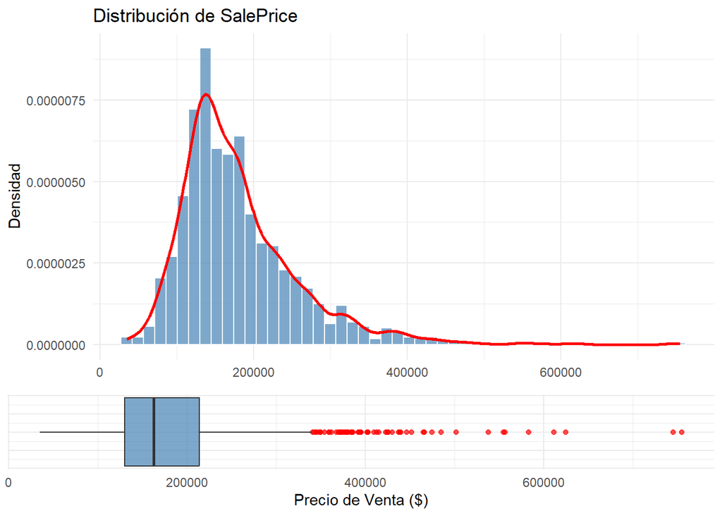

```r
# Histograma con curva de densidad
p1 <- Entrenamiento %>%
  ggplot(aes(x = SalePrice)) +
  geom_histogram(aes(y = ..density..), bins = 50, fill = "steelblue", color = "white", alpha = 0.7) +
  geom_density(color = "red", size = 1) +
  labs(title = "Distribución de SalePrice", x = NULL, y = "Densidad") +
  theme_minimal()
# Boxplot horizontal
p2 <- Entrenamiento %>%
  ggplot(aes(x = SalePrice)) +
  geom_boxplot(fill = "steelblue", outlier.color = "red", alpha = 0.7) +
  labs(x = "Precio de Venta ($)") +
  theme_minimal() +
  theme(axis.text.y = element_blank(), axis.ticks.y = element_blank())

# Combinación en la misma ventana
grid.arrange(p1, p2, ncol = 1, heights = c(3, 1))
```

El gráfico revela una clara asimetría positiva (sesgo a la derecha), donde la cola de la distribución se extiende hacia valores elevados que superan los $600,000. Esta desviación de la campana de Gauss sugiere que la varianza no es constante, lo cual compromete la eficiencia de los estimadores de mínimos cuadrados ordinarios. Para confirmar la magnitud de esta no-normalidad y validar la necesidad de una transformación logarítmica, es imperativo realizar un gráfico Q-Q y un test estadístico formal. Procederemos a contrastar la hipótesis nula de normalidad mediante el test de Anderson-Darling, analizando si los cuantiles empíricos divergen significativamente de los teóricos.

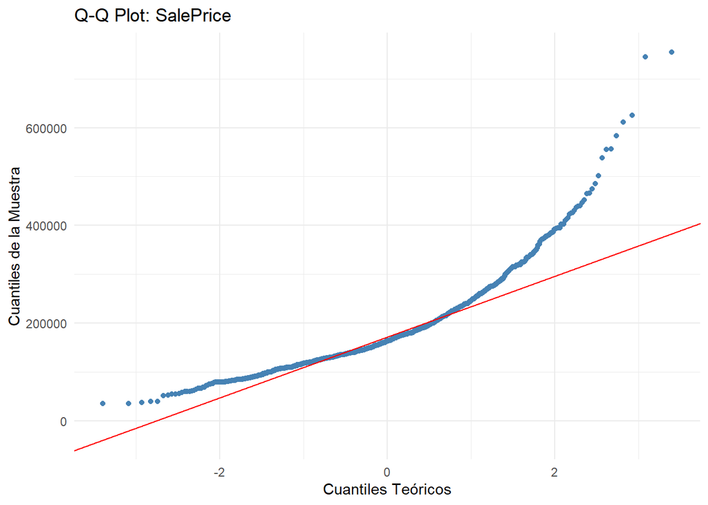

```r
Entrenamiento %>%
  ggplot(aes(sample = SalePrice)) +
  stat_qq(color = "steelblue") +
  stat_qq_line(color = "red") +
  labs(title = "Q-Q Plot: SalePrice",
       x = "Cuantiles Teóricos", y = "Cuantiles de la Muestra") +
  theme_minimal()
```

```r
# Test de Normalidad
print(ad.test(Entrenamiento$SalePrice))
```

```
##
##  Anderson-Darling normality test
##
## data:  Entrenamiento$SalePrice
## A = 41.692, p-value < 0.00000000000000022
```

La distribución de SalePrice exhibe una marcada asimetría positiva y una curtosis elevada, evidenciada por la densa cola derecha en el histograma y la proliferación de valores atípicos en el boxplot. El gráfico Q-Q Plot ratifica esta desviación, mostrando una curvatura convexa donde los cuantiles empíricos divergen drásticamente de la línea teórica de normalidad, especialmente en los extremos superiores. Dado que la prueba de Anderson-Darling rechazó formalmente la hipótesis nula de normalidad (p < 0.05), se justifica matemáticamente la aplicación de una transformación logarítmica para estabilizar la varianza y mitigar la influencia de los datos atípicos en los residuos del modelo.

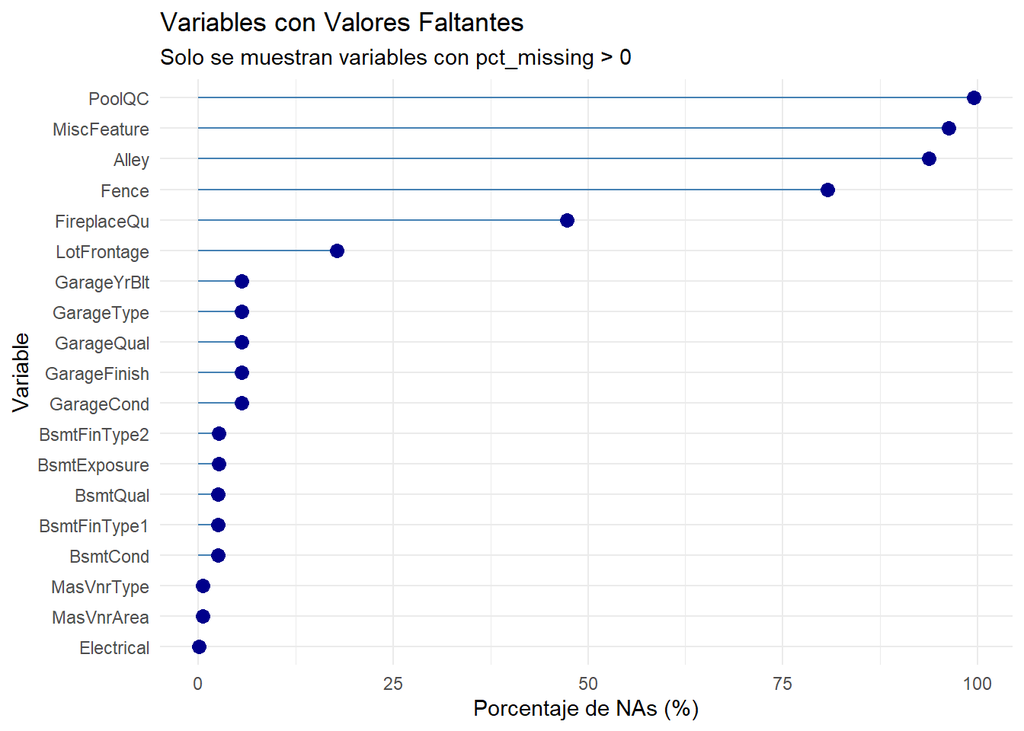

```r
df_nas <- Entrenamiento %>%
  summarise(across(everything(), ~ sum(is.na(.)) / n() * 100)) %>%
  pivot_longer(everything(), names_to = "variable", values_to = "pct_missing") %>%
  filter(pct_missing > 0) %>%
  arrange(desc(pct_missing))
df_nas %>%
  ggplot(aes(x = reorder(variable, pct_missing), y = pct_missing)) +
  geom_segment(aes(xend = variable, yend = 0), color = "steelblue") +
  geom_point(color = "darkblue", size = 3) +
  coord_flip() + # Facilita la lectura de los nombres de variables
  labs(
    title = "Variables con Valores Faltantes",
    subtitle = "Solo se muestran variables con pct_missing > 0",
    x = "Variable",
    y = "Porcentaje de NAs (%)"
  ) +
  theme_minimal()
```

El gráfico de valores faltantes revela una estructura de datos no aleatoria (MNAR), donde variables críticas como PoolQC, MiscFeature y Alley presentan una ausencia de información superior al $90\%$. Esta alta incidencia sugiere que el nulo actúa como un indicador de inexistencia del atributo, validando la estrategia de imputar categorías tipo “None” en lugar de eliminar observaciones. Para las variables con menor frecuencia de nulos, como MasVnrArea o Electrical, se confirma la viabilidad de una imputación por medidas de tendencia central sin introducir sesgos significativos. Este cribado visual permite priorizar el tratamiento de las variables con mayor impacto en la matriz de diseño, asegurando que la posterior fase de modelado trabaje sobre un espacio de características íntegro. Imputación de Datos Debido que nuestros datos estan en dos dataset (Entrenamiento y Prueba), estos dos se uniran e imputar de forma general.

```r
#decision imputar con la mediana
mediana_GarageYrBlt<-median(Entrenamiento$GarageYrBlt,na.rm = TRUE)
mediana_LotFrontage<-median(Entrenamiento$LotFrontage,na.rm = TRUE)
mediana_MasVnrArea<-median(Entrenamiento$MasVnrArea,na.rm = TRUE)
#eliminando la variabl objetivo de Entrenamiento
SalePrice<-Entrenamiento$SalePrice
Entrenamiento<-Entrenamiento%>%dplyr::select(-SalePrice)
#uniendo ambos data para la imputacion general
Entrenamiento$origen<-"Train"
Prueba$origen<-"Test"
full_data<-bind_rows(Entrenamiento,Prueba)
#imputacion de las variables numericas
full_data<-full_data%>%mutate(
  LotFrontage=replace_na(LotFrontage,mediana_LotFrontage),
  MasVnrArea=replace_na(MasVnrArea,mediana_MasVnrArea),
  GarageYrBlt=replace_na(GarageYrBlt,mediana_GarageYrBlt)
)
#imputando las variables tipo caracter
full_data<-full_data%>%mutate(
  across(where(is.character),~replace_na(.,"None")))
```

Verificando si quedan variables con NAs

```r
library(kableExtra)
#Procesamiento de los datos para la tabla
resumen_nas <- Entrenamiento %>%
  summarise(across(everything(), ~ sum(is.na(.)))) %>%
  pivot_longer(everything(), names_to = "Variable", values_to = "Total_NAs") %>%
  filter(Total_NAs > 0) %>% # Filtrar solo las que tienen NAs
  arrange(desc(Total_NAs)) %>%
  mutate(Porcentaje = round((Total_NAs / nrow(Entrenamiento)) * 100, 2))

#Renderizado de tabla elegante
resumen_nas %>%
  kbl(caption = "Inventario de Datos Faltantes en el Dataset de Entrenamiento",
      col.names = c("Variable", "Cantidad de NAs", "Porcentaje (%)"),
      align = "lrr") %>%
  kable_styling(bootstrap_options = c("striped", "hover", "condensed", "responsive"),
                full_width = F,
                position = "center") %>%
  column_spec(2, bold = T, color = "white", background = "#2c3e50") %>%
  scroll_box(height = "400px") # Útil si la lista es larga
```

Inventario de Datos Faltantes en el Dataset de Entrenamiento

| Variable | Cantidad de NAs | Porcentaje (%) |
| --- | --- | --- |
| PoolQC | 1453 | 99.52 |
| MiscFeature | 1406 | 96.30 |
| Alley | 1369 | 93.77 |
| Fence | 1179 | 80.75 |
| FireplaceQu | 690 | 47.26 |
| LotFrontage | 259 | 17.74 |
| GarageType | 81 | 5.55 |
| GarageYrBlt | 81 | 5.55 |
| GarageFinish | 81 | 5.55 |
| GarageQual | 81 | 5.55 |
| GarageCond | 81 | 5.55 |
| BsmtExposure | 38 | 2.60 |
| BsmtFinType2 | 38 | 2.60 |
| BsmtQual | 37 | 2.53 |
| BsmtCond | 37 | 2.53 |
| BsmtFinType1 | 37 | 2.53 |
| MasVnrType | 8 | 0.55 |
| MasVnrArea | 8 | 0.55 |
| Electrical | 1 | 0.07 |

Imputando de manera general, las variables numericas con la mediana y las variables categoricas con None

```r
vars_num_con_na<-full_data%>%dplyr::select(where(is.numeric))%>%dplyr::summarise(across(everything(),
              ~sum(is.na(.))))%>%tidyr::gather(variable,conteo)%>%dplyr::filter(conteo>0)%>%dplyr::pull(variable)
for(col in vars_num_con_na){
  mediana<-median(Entrenamiento[[col]],na.rm = TRUE)
  full_data[[col]][is.na(full_data[[col]])]<-mediana
  print(paste("Imputada variable:",col,"con valor:",mediana))
}
```

```
## [1] "Imputada variable: BsmtFinSF1 con valor: 383.5"
## [1] "Imputada variable: BsmtFinSF2 con valor: 0"
## [1] "Imputada variable: BsmtUnfSF con valor: 477.5"
## [1] "Imputada variable: TotalBsmtSF con valor: 991.5"
## [1] "Imputada variable: BsmtFullBath con valor: 0"
## [1] "Imputada variable: BsmtHalfBath con valor: 0"
## [1] "Imputada variable: GarageCars con valor: 2"
## [1] "Imputada variable: GarageArea con valor: 480"
```

Separando los dataset.

```r
Entrenamiento_limpio<-full_data%>%dplyr::filter(origen=="Train")%>%dplyr::select(-origen)
Prueba_limpio<-full_data%>%dplyr::filter(origen=="Test")%>%dplyr::select(-origen)
Entrenamiento_limpio$SalePrice<-SalePrice
```